# Time series tutorial - R in Grenoble session

A.ZAHER

2021-05-29

The most relevant packages are: lattice, latticeExtra, and ggplot2 for static graphics; zoo and xts for reading and arranging data as time series; RColorBrewer for defining color palettes; and packages dygraphs, highcharter, and plotly, based on the htmlwidgets framework, to generate animations or interactive graphics.

```r
library(lattice)
library(ggplot2)
# latticeExtra must be loaded after ggplot2 to prevent masking of `layer`
library(latticeExtra)
library(RColorBrewer)




library(zoo)
```

And this is the data we will use:

- aranjuez.RData
- navarra.RData
- CO2.RData

```r
## loading from Github

# library(repmis)
#
# source_data("https://github.com/zaher-stat/R_in_Grenoble-Time_Series_Talk/blob/ZAHER_Ahmed/aranjuez.RData?raw=True")
# source_data("https://github.com/zaher-stat/R_in_Grenoble-Time_Series_Talk/blob/ZAHER_Ahmed/navarra.RData?raw=True")
# source_data("https://github.com/zaher-stat/R_in_Grenoble-Time_Series_Talk/blob/ZAHER_Ahmed/CO2.RData?raw=True")

## loading from local repository

load('aranjuez.RData')
load('navarra.RData')
load('CO2.RData')
```

# Visualization of a Time Series

The most frequent visualization method of a time series uses the horizontal axis to depict the time index. This section illustrates two variants of this approach to display multivariate time series: multiple time series with different scales, and variables with the same scale.

## Time graph of variables with different scales

For the first example we will use the eight years of daily data from a meteorological station located at Aranjuez (Madrid). This multivariate time series can be displayed with the `xyplot` method of lattice for `zoo` objects with a panel for each variable.

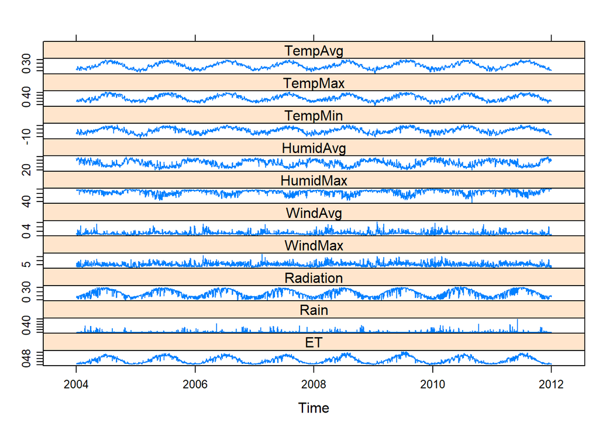

```r
## The layout argument arranges panels in rows
xyplot(aranjuez, layout = c(1, ncol(aranjuez)))
```

The package `ggplot2` provides the generic method `autoplot` to automate the display of certain classes with a simple command.

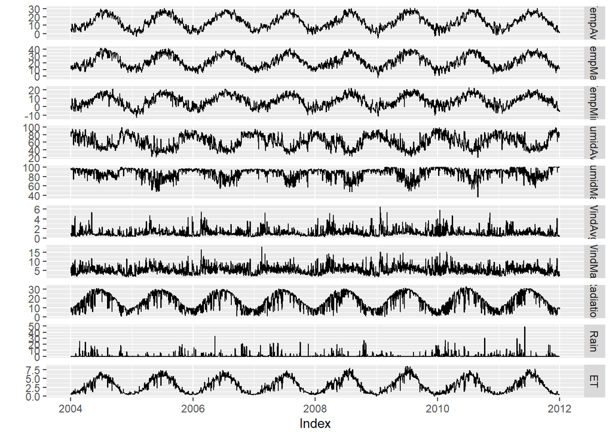

```r
## facet_free allows each panel to have its own range
ggplot2::autoplot(aranjuez) + facet_free()
```

# Time series of variables with the same scale

As an example of time series of variables with the same scale, we will use measurements of solar radiation from different meteorological stations.

The first attempt to display this multivariate time series makes use of the xyplot.zoo method. The objective of this graphic is to display the behavior of the collection as a whole: the series are superposed in the same panel (superpose=TRUE) without legend (auto.key=FALSE), using thin lines and partial transparency. Transparefncy softens overplotting problems and reveals density clusters because regions with more overlapping lines are darker. Next code displays the variations around the time average (avRad).

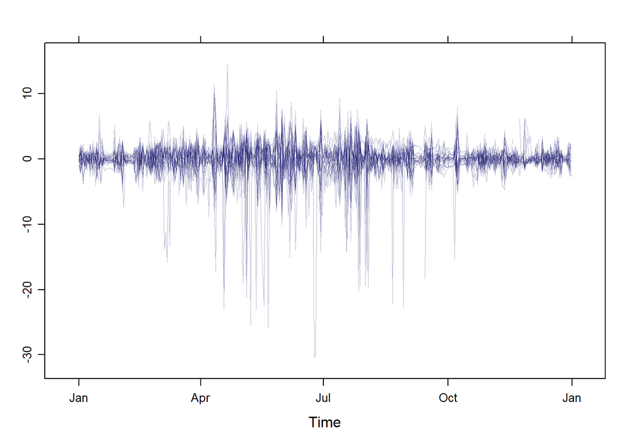

```r
avRad <- zoo(rowMeans(navarra, na.rm = 1), index(navarra))
pNavarra <- xyplot(navarra - avRad,
        superpose = TRUE, auto.key = FALSE,
        lwd = 0.5, alpha = 0.3, col = 'midnightblue')
pNavarra
```

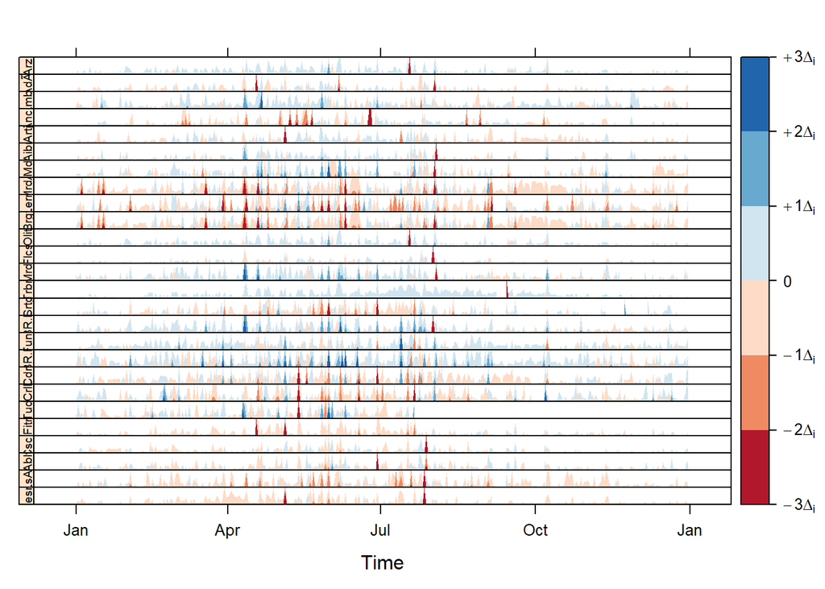

```r
horizonplot(navarra - avRad,
            layout = c(1, ncol(navarra)),
            origin = 0, ## Deviations in each panel are calculated
                        ## from this value
            colorkey = TRUE,
            col.regions = brewer.pal(6, "RdBu"))
```

# Interactive graphics

```r
library(widgetframe)
```

```r
library(dygraphs)

dyTemp <- dygraph(aranjuez[, c("TempMin", "TempAvg", "TempMax")],
       main = "Temperature in Aranjuez",
       ylab = "ºC")

widgetframe::frameWidget(dyTemp)
```

[interactive chart not shown]

```r
dygraph(aranjuez[, c("TempMin", "TempAvg", "TempMax")],
 main = "Temperature in Aranjuez",
 ylab = "ºC") %>%
   dySeries(c("TempMin", "TempAvg", "TempMax"),
      label = "Temperature") %>%
  widgetframe::frameWidget()
```

[interactive chart not shown]

```r
library(highcharter)
library(xts)

aranjuezXTS <- as.xts(aranjuez)

highchart() %>%
   hc_add_series(name = 'TempMax',
           aranjuezXTS[, "TempMax"]) %>%
   hc_add_series(name = 'TempMin',
           aranjuezXTS[, "TempMin"]) %>%
   hc_add_series(name = 'TempAvg',
           aranjuezXTS[, "TempAvg"]) %>%
  widgetframe::frameWidget()
```

[interactive chart not shown]

```r
aranjuezDF <- fortify(aranjuez[,
            c("TempMax",
              "TempAvg",
              "TempMin")],
           melt = TRUE)

summary(aranjuezDF)
```

```
##      Index                Series         Value
##  Min.   :2004-01-01   TempMax:2898   Min.   :-12.980
##  1st Qu.:2005-12-29   TempAvg:2898   1st Qu.:  7.107
##  Median :2008-01-09   TempMin:2898   Median : 13.560
##  Mean   :2008-01-03                  Mean   : 14.617
##  3rd Qu.:2010-01-03                  3rd Qu.: 21.670
##  Max.   :2011-12-31                  Max.   : 41.910
##                                      NA's   :10
```

```r
library(plotly)
plot_ly(aranjuezDF) %>%
   add_lines(x = ~ Index,
       y = ~ Value,
       color = ~ Series) %>%
  widgetframe::frameWidget()
```

[interactive chart not shown]